# Solutions

### Exercise 1

In this exercise we're using the data in BoltData.csv to find out how fast Usain Bolt runs in 100 m.

First we need to read in the data using `np.loadtxt`, and check that it's read in as expected.

```
dist, dist_unc, time, time_unc = np.loadtxt('./data/BoltData.csv', unpack=True, skiprows=1, delimiter=',')
```

```
print(dist, dist.shape)
print(dist_unc, dist_unc.shape)
print(time, time.shape)
print(time_unc, time_unc.shape)
```

```
[  0.  10.  20.  30.  40.  50.  60.  70.  80.  90. 100.] (11,)
[0.02 0.02 0.02 0.02 0.02 0.02 0.02 0.02 0.02 0.02 0.02] (11,)
[0.         0.9234224  2.17814477 2.46189746 3.38705138 5.26387915
 6.04270515 7.93919241 8.22177923 8.57812847 9.56287374] (11,)
[1.0048096  0.63756914 0.38236597 0.91178482 0.19851041 1.15222207
 0.16182731 0.732011   1.26732922 0.59090761 1.02233664] (11,)
```

The next thing to do is to **plot the data**. Get in the habit of plotting your data frequently. It's much easier to see if it looks like you expect from a plot than by staring at numbers on a screen.

```
fig = plt.figure(figsize=(10,6))
ax = fig.add_subplot(1,1,1)
ax.errorbar(dist, time, yerr=time_unc, marker='o', ms=4,c='k', ls='None', capsize=4, label='Data')
ax.set_ylabel('Time (s)')
ax.set_xlabel('Distance (m)')
ax.legend(loc='upper left')
plt.show()
```

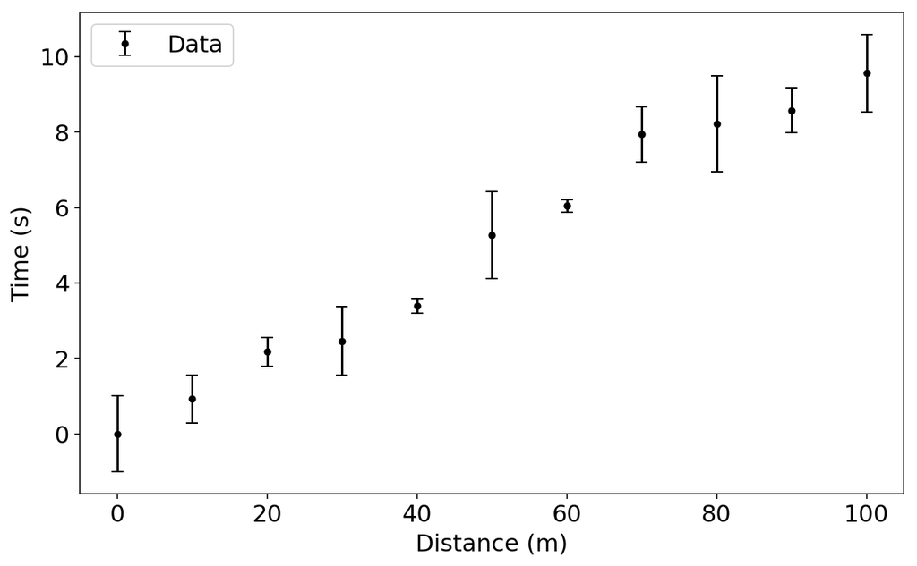

## Measuring the speed

We want to measure the speed from the time and distance data:

$$v = \dfrac{d}{t}$$

We can do this by fitting a function of the form $y = m x + c$ to our data.

$$ t = \dfrac{d}{v} + c$$

Why is there a constant, $c$, in this function if we know that $t = \dfrac{d}{v}$? We don't know how the data was taken, so it may be that the timer didn't start at the exact time Bolt started running, so $c$ takes this into account.

Now set up our function:

```
def time_run(d, v, c):
    return d / v + c
```

and now we can find the value of $v$ and it's associated uncertainty $\sigma_v$ (and $c$, $\sigma_c$) using `curve_fit`

```
popt, pcov = curve_fit(time_run, dist, time)
speed = popt[0]
speed_unc = pcov[0][0]
intercept = popt[1]
int_unc = pcov[1][1]
print(speed, speed_unc)
print(intercept, int_unc)
```

```
9.984175690191293 0.20643331413262758
-0.04800892191601898 0.07271120631997624
```

Now we can re-plot our data with our best fit line and have the speed printed out in the title. We can save the plot using `plt.savefig`

```
fig = plt.figure(figsize=(10,6))
ax = fig.add_subplot(1,1,1)
ax.plot(dist, time_run(dist, speed, intercept), 'b-', label='Best Fit')
ax.errorbar(dist, time, yerr=time_unc, marker='o', ms=4,c='k', ls='None', capsize=4, label='Data')
ax.set_ylabel('Time (s)')
ax.set_xlabel('Distance (m)')
title_string = "$v = {0:.2f} \pm {1:.2f}$ m s$^{{-1}}$".format(speed, speed_unc)
ax.set_title(title_string)
ax.legend(loc='upper left')
plt.show()
plt.savefig('Bolt_plot.png', dpi=300)
```

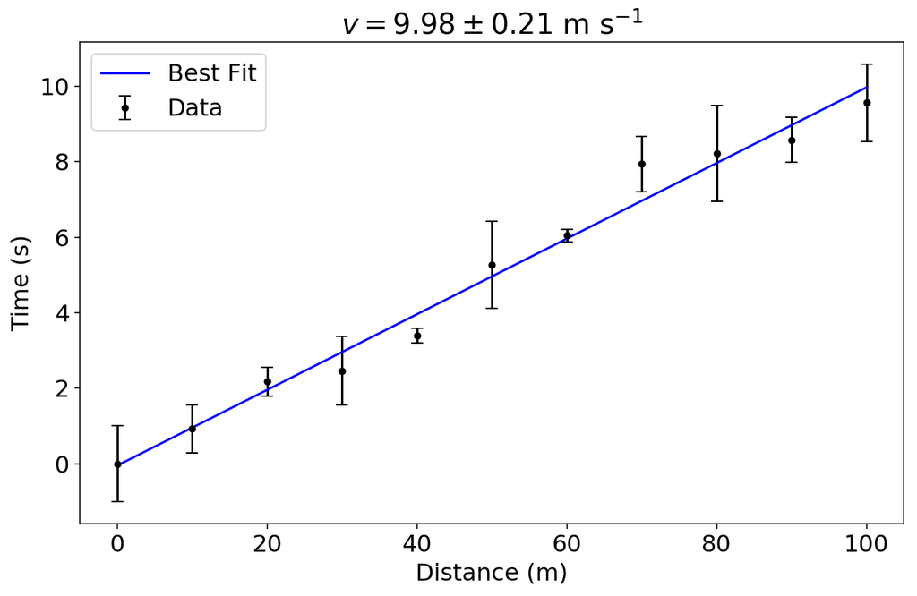